# Mass Shootings in the U.S. 1966 - 2017 by Jesse Montgomery

Here, I analyze the Stanford Mass Shootings in America (MSA) dataset found on  
Kaggle.com (https://www.kaggle.com/carlosparadis/stanford-msa). This includes  
data of mass shootings (defined as 3 or more victims) occuring in the United  
States between 1966 and 2016. This is described as a high-quality, but not  
comprehensive dataset. To capture recent shootings not included in this  
dataset, I added data from the US Mass Shootings dataset  
(https://www.kaggle.com/zusmani/us-mass-shootings-last-50-years). This an open  
dataset that is continually updated, but of lower quality. To explore  
additional variables, I combined this dataset with US census data  
(https://www2.census.gov/programs-surveys/popest/datasets/2010-2016/cities/\ totals/sub-est2016_all.csv) as well as climate data from the National Oceanic  
and Atmosphere Administration  
(https://www1.ncdc.noaa.gov/pub/data/ccd-data/nrmavg.txt).

# Univariate Plots Section

I will break the univariate analysis up in five sections:

1. The magnitude of shootings. What is the distribution of those killed/injured?
   - Total number of fatalities
   - Total number of inuries
2. Shootings over time. Are more shootings happening? Is there a  
   seasonality?
   - By day of the week
   - By year
   - By month
3. Location. Where do mass shootings occur most often? Are there common  
   characteristics about the places?
   - State
   - City
   - Population
   - Type of place
4. Weapons. Are there types of weapons that are used more than others? Would  
   gun control be more effective for a type of gun?
   - Type of gun
   - Number of guns
5. Shooter demographics. Are there common characteristics among shooters?
   - Race
   - Age
   - History of mental illness
   - Possible motives
   - Targeted victims

## 1. Magnitude of Shootings

### Variable Summaries

Number of fatalities and number of victims injured.

|  | Total.Number.of.Fatalities | Number.of.Victims.Injured |
| --- | --- | --- |
|  | Min. : 0.000 | Min. : 0.000 |
|  | 1st Qu.: 2.000 | 1st Qu.: 1.000 |
|  | Median : 4.000 | Median : 3.000 |
|  | Mean : 4.709 | Mean : 6.192 |
|  | 3rd Qu.: 6.000 | 3rd Qu.: 5.000 |
|  | Max. :59.000 | Max. :527.000 |

There is a very large difference between Max and all other stats for each of  
these variables indicating some outliers or a very skewed distribution. Let’s  
take a look.

### Plots of Fatalities and Victims

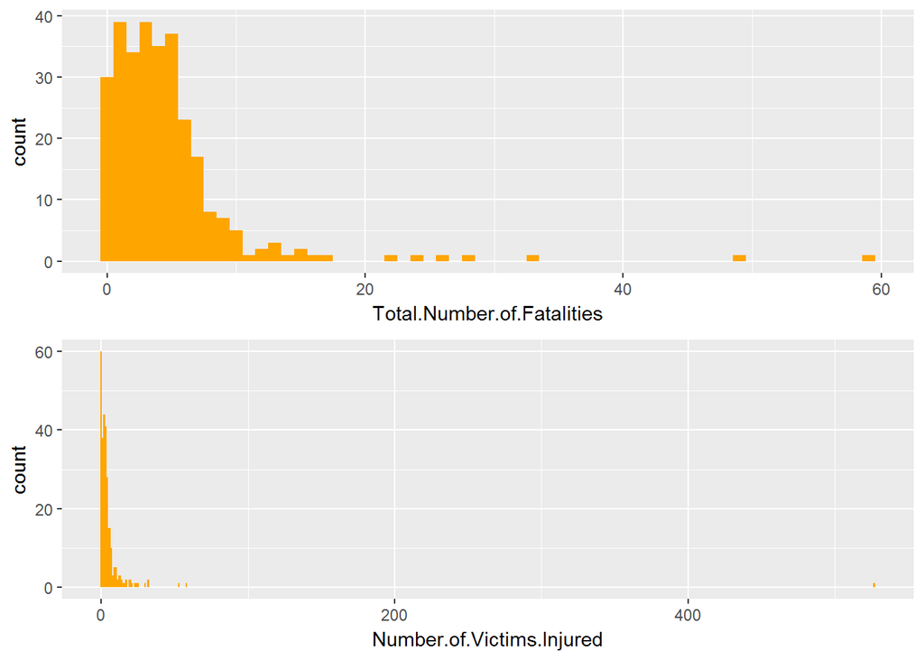

There are several outliers. The most extreme is the shooting with over 500  
injured victims. Let’s see what shooting this is.

|  | Title | Date…Detailed | Location | Total.Number.of.Fatalities | Number.of.Victims.Injured |
| --- | --- | --- | --- | --- | --- |
| 318 | Las Vegas Strip mass shooting | Sunday, October 01, 2017 | Las Vegas, NV | 59 | 527 |

It is no surprise that this was the recent shooting in Las Vegas, the most  
deadly in history. It also accounts for the highest fatality outlier.

This is one analysis where outliers cannot be ignored. But to visualize the  
distributuion of other shootings better, I will plot the lower 90% of data.

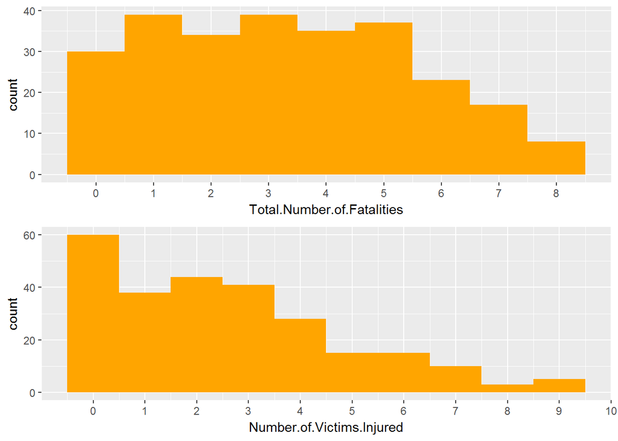

The distribution for mass shootings is skewed to the right. Most shootings tend  
to have less victims.

Let’s look at the magnitude of the top 5 mass shootings, including when and  
where they occurred. I will define the top 5 mass shootings as those with the  
greatest number of fatalities.

|  | Title | Date…Detailed | Location | Total.Number.of.Fatalities | Number.of.Victims.Injured |
| --- | --- | --- | --- | --- | --- |
| 318 | Las Vegas Strip mass shooting | Sunday, October 01, 2017 | Las Vegas, NV | 59 | 527 |
| 308 | Orlando nightclub massacre | Sunday, June 12, 2016 | Orlando, Florida | 49 | 53 |
| 98 | Virginia Tech Campus | Monday, April 16, 2007 | Blacksburg, Virginia | 33 | 17 |
| 138 | Sandy Hook Elementary School | Friday, December 14, 2012 | Newtown, Connecticut | 28 | 2 |
| 321 | Texas church mass shooting | Sunday, November 05, 2017 | Sutherland Springs, TX | 26 | 20 |

With the exception of the mass shooting at Virginia Tech, the most severe  
shootings have occured in the last 5 years. It is a grim trend to consider.

## 2. Shootings Over Time

### Variable Summaries

Year, day of the week, and the month.

|  | Year | Day.of.Week | Month |
| --- | --- | --- | --- |
|  | Min. :1966 | Sunday :48 | Feb : 46 |
|  | 1st Qu.:1999 | Monday :40 | Mar : 34 |
|  | Median :2013 | Tuesday :34 | Dec : 28 |
|  | Mean :2007 | Wednesday:42 | Apr : 27 |
|  | 3rd Qu.:2015 | Thursday :51 | Jan : 25 |
|  | Max. :2017 | Friday :48 | Oct : 23 |
|  | NA | Saturday :29 | (Other):109 |

The median year being very near the Max indicates a skewed distribution.There  
doesn’t appear to be an obvious trend with day of the week, except that mass  
shootings are less common on Tuesday and Saturday. Winter and Spring  
months appear to have more shootings.

### Shootings by Year

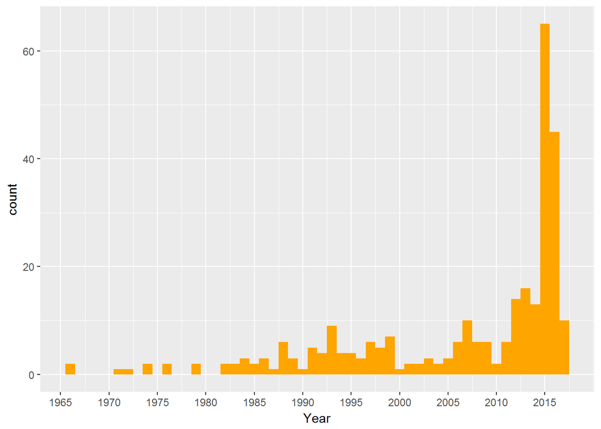

The distribution is certainly skewed to the left. It looks like there has  
been an increase in the last five years with a major spike in 2015 and 2016. It  
would appear that things are getting worse.

### Shootings by Day of the Week

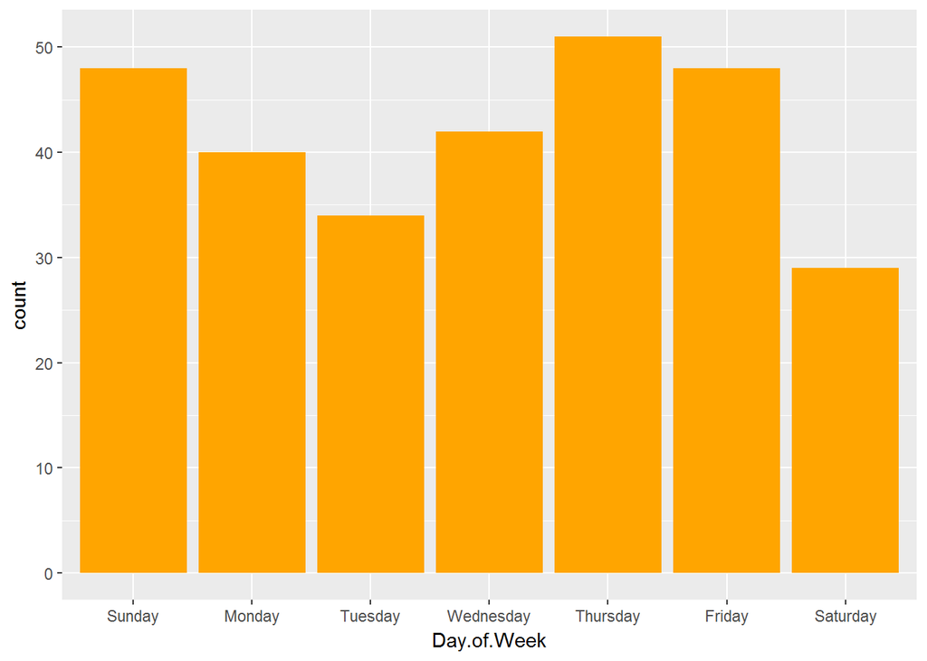

Perhaps Tuesday and Saturday are safer days to be in public?

### Shootings by Month

How about month? Is there a seasonality to mass shootings?

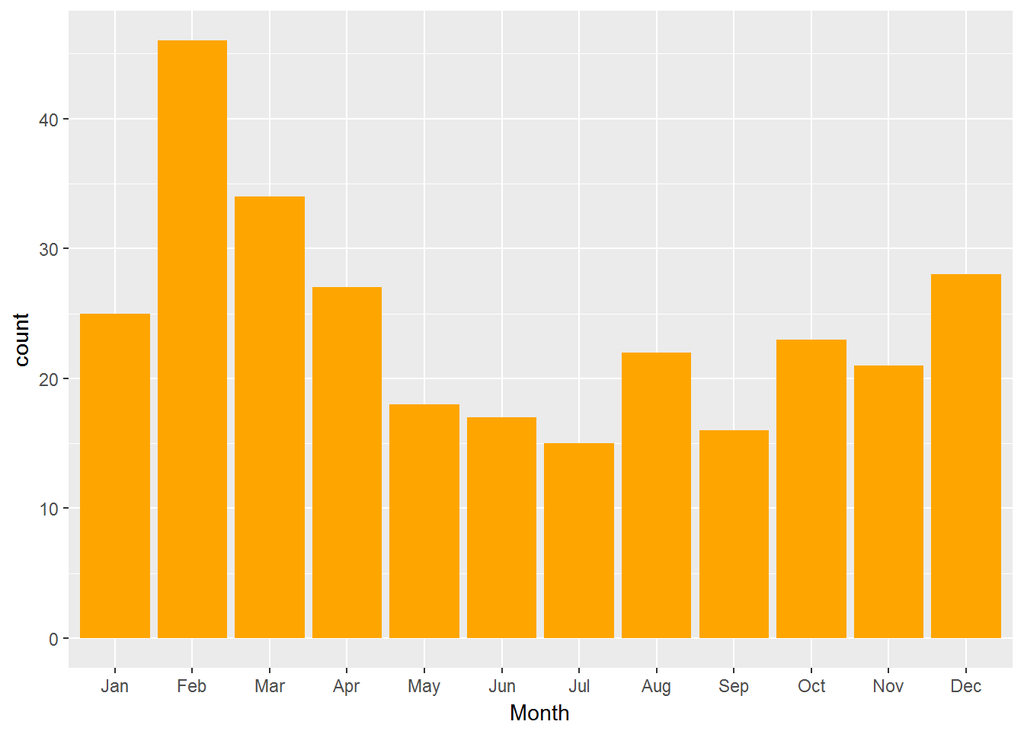

Indeed, it does appear that most shootings occur in winter and early spring  
months with the exception of January. This surprises me. I think of mass  
shootings being random attacks at large gatherings which I picture occuring  
outdoors more often during the summer. Perhaps depression influenced by darker  
and colder months is a factor. Let’s see if temperature is a factor. I have  
created a column of the likely temperature that month in the area pulled from  
National Oceanic and Atmospheric Administration (NOAA) climate data.

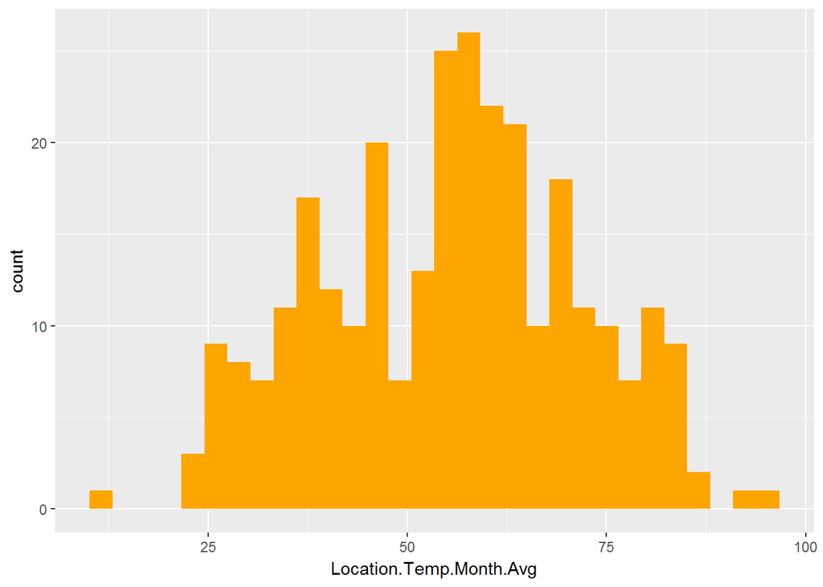

There is a fairly normal distribution centered about 55 degrees, which is  
the average annual temperature in the United States (55.7 $^\circ$F,  
https://www.usclimatedata.com). If colder temperatures were a contributing  
factor, I would expect data to be skewed to the right or at least the mean  
shifted to the left of the national average temperature.

## 3. Shootings by Location

### Variable Summaries

State, city, population, and type of place.

|  | State | City | Population | Place.Type |
| --- | --- | --- | --- | --- |
|  | California: 31 | Phoenix : 5 | Min. : 287 | Residential home/Neighborhood :92 |
|  | Florida : 21 | Albuquerque: 4 | 1st Qu.: 22584 | College/University/Adult education:27 |
|  | Texas : 20 | Killeen : 4 | Median : 97227 | Company/Factory/Office :23 |
|  | Georgia : 15 | Las Vegas : 4 | Mean : 328362 | Secondary school :22 |
|  | Washington: 14 | New Orleans: 4 | 3rd Qu.: 399457 | Government facility :21 |
|  | Arizona : 12 | Seattle : 4 | Max. :3792621 | Retail/Wholesale/Services facility:21 |
|  | (Other) :179 | (Other) :267 | NA’s :22 | (Other) :86 |

Let’s at the locations of mass shootings. First by state.

### Shootings by State

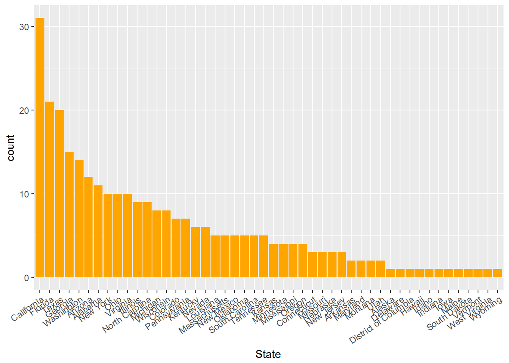

The top 3-5 states tower over the rest. The top 5 states account for 35% of  
all shootings. Is there something unique about these locations?

### Shootings by City

Mass shootings are concentrated in a few states. Are they repeated in  
individual cities? Again, we will order the histogram by frequency.

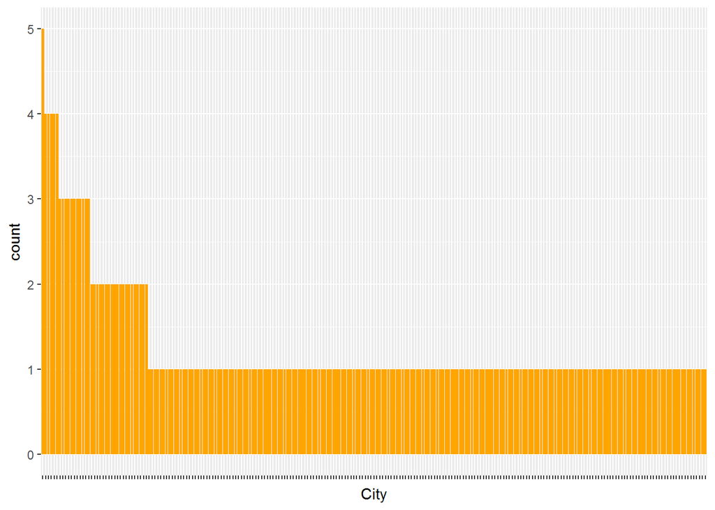

Fewer than a quarter of the cities have more than one incident. Let’s zoom in  
on those.

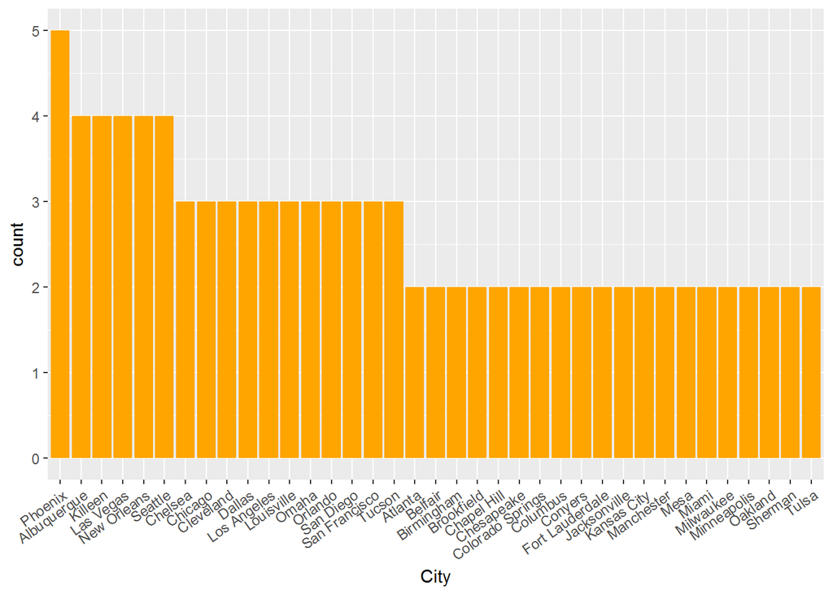

There are several highly populated cities in this list, but that isn’t the  
case for all of them.

Now let’s look at the population of cities with mass shootings.

### Shootings and Population

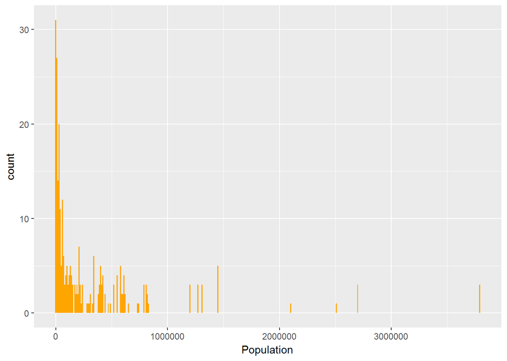

There are a handful of cities with very high populations. Let’s look at the  
lower 90%

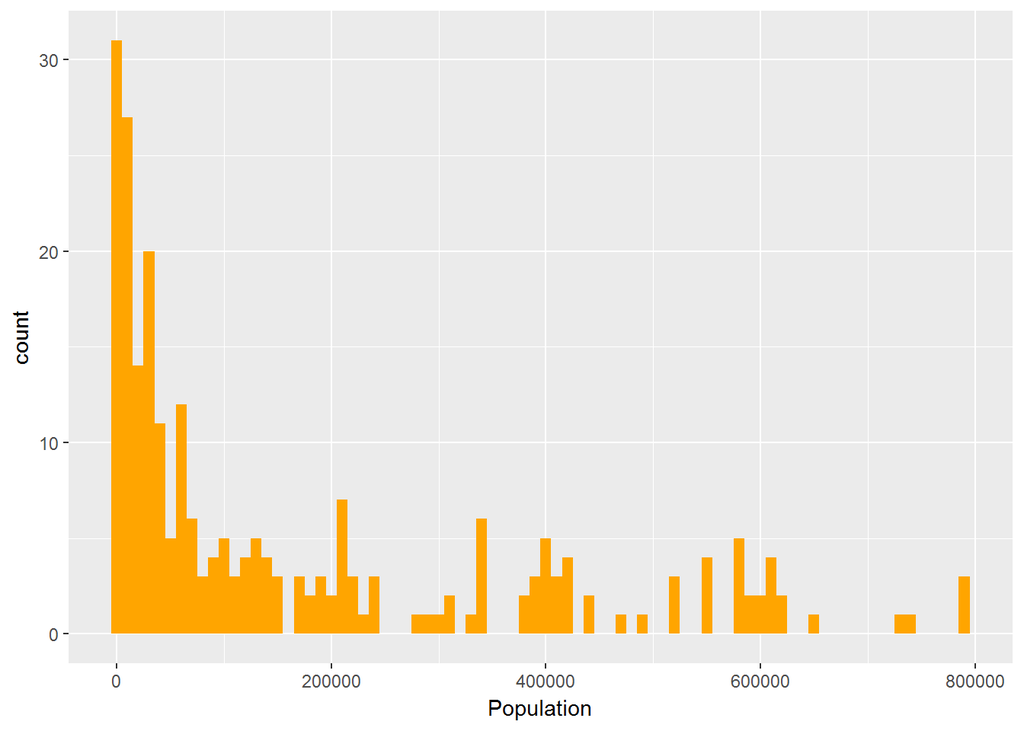

The distribution is skewed to the right. Mass shootings occur more frequently in  
cities with lower populations. Half of them occur in cities with less than  
100,000 people.

### Shootings by Type of Place

What types of locations or facilities are most frequently targeted by shooters?

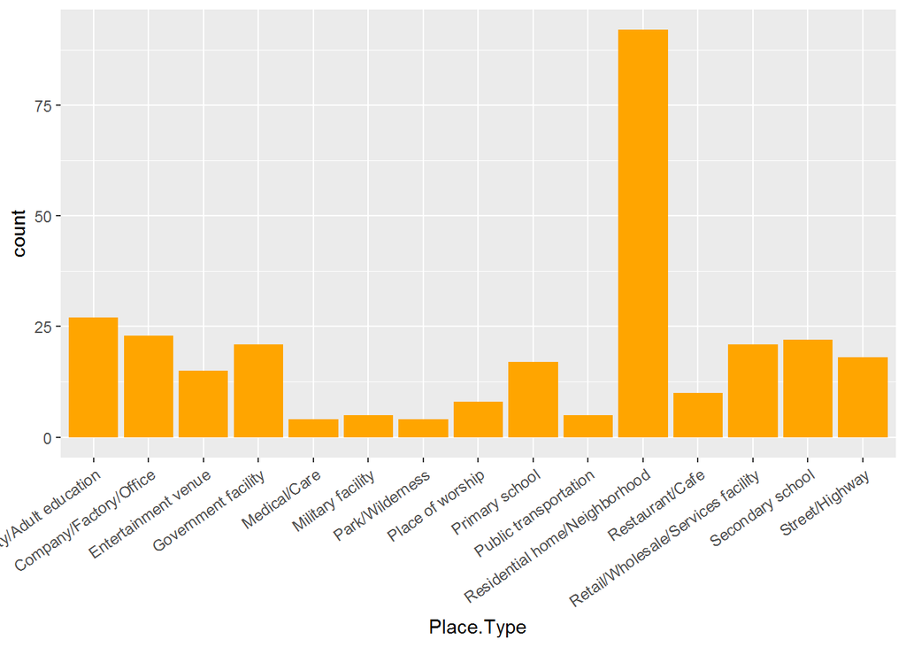

Neighborhoods are the most frequently targeted. Places of business, education  
and government are also common.

## 4. Weapons

What weapons were involved in mass shootings? Should gun control efforts be  
placed on certain types of weapons?

Number of each type of gun.

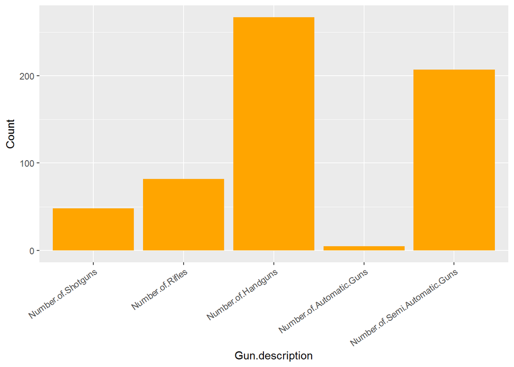

Handguns guns are the most common weapons. Automatic and semi-automatic are  
likely a subcategories of the other three gun types. Gun control efforts  
would probably be best concentrated on handguns and especially those that are  
semi-automatic.

## 5. Shooter Deomographics

Do shooters have anything in common?

### Variable Summaries

Race, age, history of mental illness, possible motives

|  | Shooter.Race | Average.Shooter.Age | History.of.Mental.Illness…General | Possible.Motive…General |
| --- | --- | --- | --- | --- |
|  | White American or European American:137 | Min. :12.00 | No :96 | Unknown :71 |
|  | Black American or African American : 76 | 1st Qu.:21.00 | Unknown:97 | Mental illness :33 |
|  | Some other race : 23 | Median :30.00 | Yes :99 | Multiple motives :32 |
|  | Unknown : 21 | Mean :31.66 | NA | Domestic dispute :30 |
|  | Asian American : 17 | 3rd Qu.:41.00 | NA | Social dispute :30 |
|  | White : 5 | Max. :70.00 | NA | Terminated/Denied/Reprimanded:23 |
|  | (Other) : 13 | NA | NA | (Other) :73 |

### Race

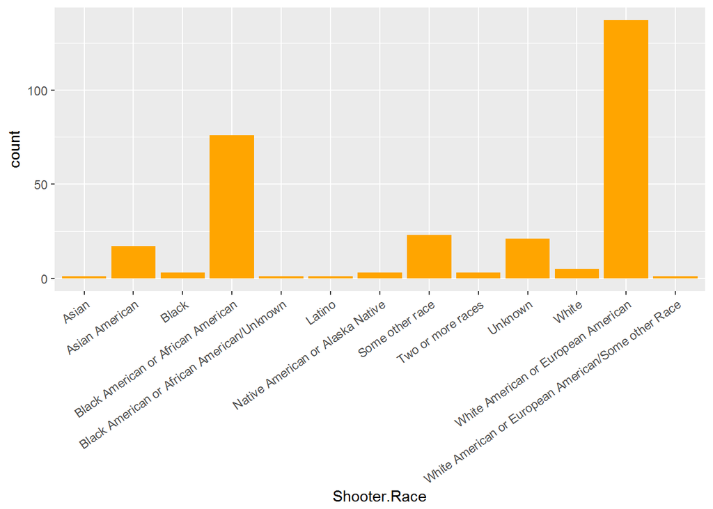

Races besides White and African American are few.

### Age

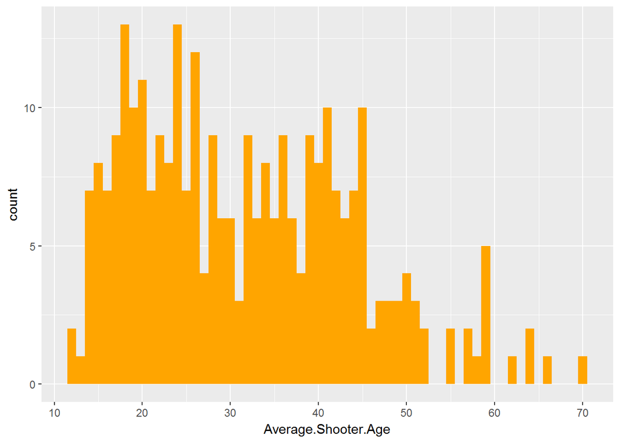

### Possible Motive

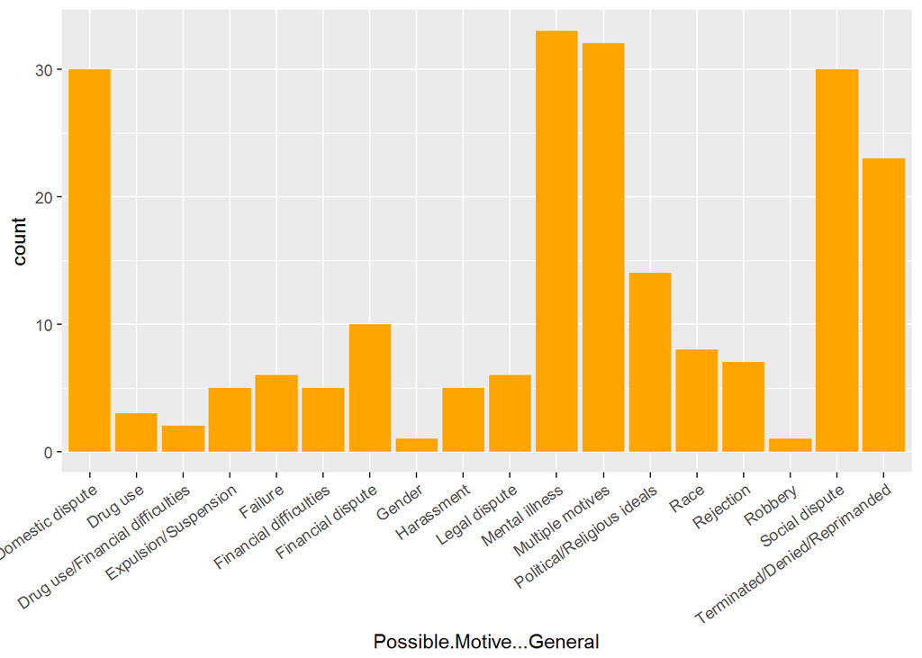

Four distinct categories are dominant, excluding multiple motives. The multiple  
motives category includes more than one of the categories. For example, one  
such shooting involved a young man that was bullied (social dispute) and had a  
history of mental illness. Most of those labeled multiple motives are a  
combination of these top four motives.

1. Mental illness
2. Domestic dispute
3. Social dispute
4. Terminated/Denied/Reprimanded.

### Targeted Victims

Who do shooters target?

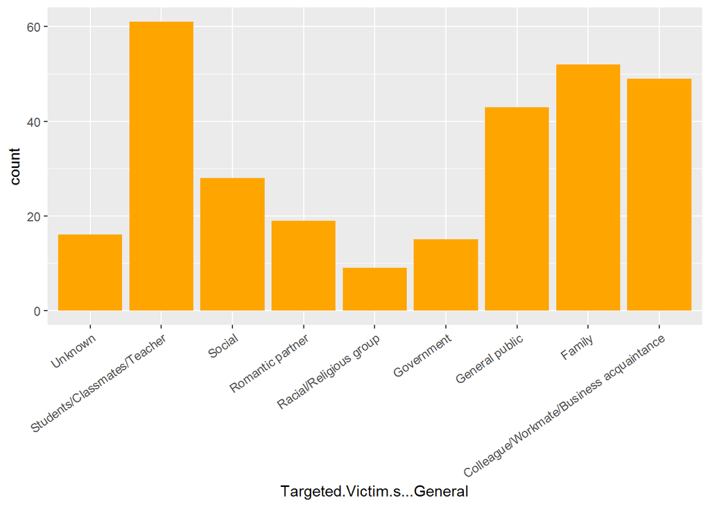

Four types of victims stand above the rest:

1. School associates (Students/Classmates/Teacher)
2. Family
3. Business associates (Colleague/Workmate/Business acquaintance)
4. General public

# Univariate Analysis

### What is the structure of your dataset?

The data is tidy, long-form data where each row is an observation (shooting  
event) and each column is a feature of the observation. There are not many  
missing values for each feature, making this a good dataset from which to  
draw conclusions.

### What is/are the main feature(s) of interest in your dataset?

The main features of interest are the number of fatalities and the number of  
injuries.

### What other features in the dataset do you think will help support your investigation into your feature(s) of interest?

To further understand this dataset, I would like to also look at geographical  
distribution of the shootings and the type of place that shootings occurred.

### Did you create any new variables from existing variables in the dataset?

I did not create any new variables from the dataset, but I did pull in other  
variables I was interested in. I pulled population data from a U.S. Census  
and climate data from NOAA. I was able to match up location to these additional  
by the longitude and latitude (climate) and city and state names (population)  
in my primary dataset.

### Of the features you investigated, were there any unusual distributions? Did you perform any operations on the data to tidy, adjust, or change the form of the data? If so, why did you do this?

The most striking observation for me was the increase in shooting attacks over  
time. It hints at great public danger for the future. I also found the  
population distribution interesting. Less populated areas are more prone to  
mass shootings.

I had to rearrange the data to sum the types of weapons used in shootings. This  
was necessary to arrange the data into a single column that could be easily  
plotted in ggplot2. Other tidying included declaring numeric columns that were  
imported as strings and converting string columns with distinct levels into  
factors.

# Bivariate Plots Section

### Number of Fatalities with Time

The histogram of shootings with time showed that shootings are increasing in  
frequency. Are these shootings becoming more deadly? First, let’s look at the  
number of fatalities with time.

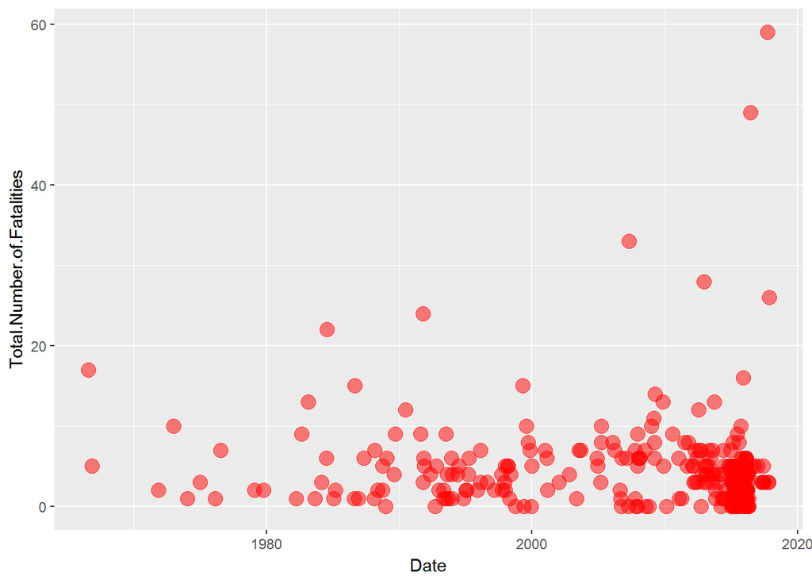

While there are some shootings within the past decade with higher fatalities  
than previous years, most shootings appear to have similar fatalities with the  
majority having less than 10.

### Number of Victims with Time

Let’s look at the same for number of victims  
(fatalities + injuries). The Las Vegas shooting in October is a serious  
outlier in this metric. To get a better look at other shootings, I will  
remove it.

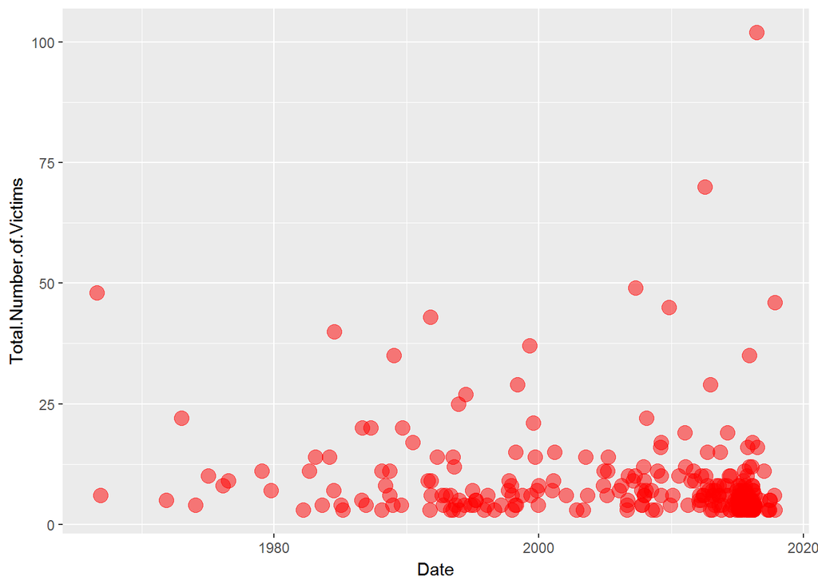

Plots of Total Victims and Total Fatalities with time look very similar. There  
are some shootings within the last 5 to 10 years with higher numbers. However,  
it is not clear if there is a definite trend of mass shootings towards  
increasing severity. It is possible that recent shootings are outliers that  
do not reflect future activity. We can only hope this is the case.

### Geographic Distribution of Fatalities

Let’s see how fatalities are distributed across the country.

[figure not shown]

Shootings are concentrated mostly along the Eastern United States and the West  
Coast with a cluster in Southeast Texas. Fewer shootings have occured in the  
Midwest and Central United States and may be influenced by more sparse  
population density in these regions. Still, shootings have occured in remote  
areas. There are several regions with dense clusters, indicating a large number  
of fatalities. Some that stand out to me are Southern California, Southern  
Florida, Southeast Texas, and Northwest Washington.

### Place Type and Shooter Age

What type of places do these shootings occur at? Are different types of places  
targeted by different age demograpics? Let’s look at this with a box plot.

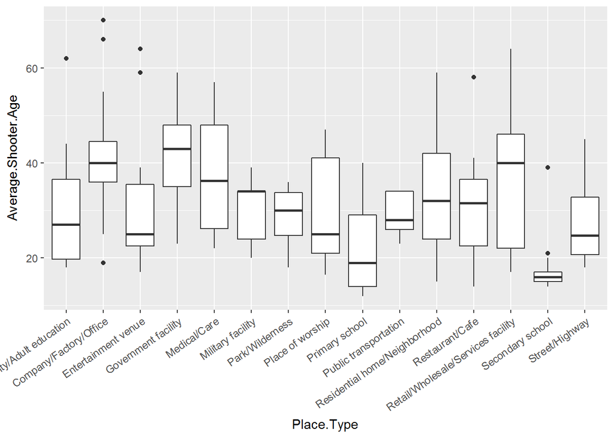

Places of work (Company/Factory/Office) and government facilities are targeted  
by older shooters while primary and secondary schools are targeted by younger  
shooters. Retail facilities and residential neighborhoods have the broadest  
distributions and are targeted by shooters of all ages.

### Motive and age

Do shooters of different ages have different motives?

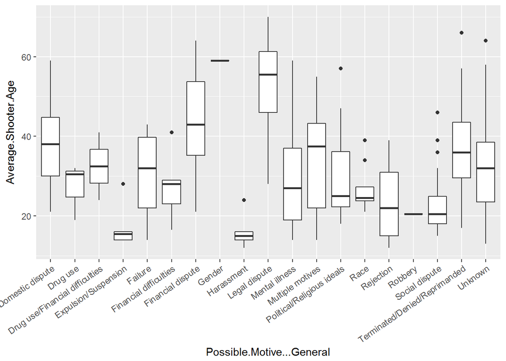

The youngest shooters were motivated by expulsion or suspension from school and  
harassment. Other motivations for younger shooters include drug use, financial  
difficulties, race, and social disputes. Older shooters were motivated most by  
financial and legal disputes.

### Age Group and Total Victims

The previous two plots lead to the question what is the most deadly age group?

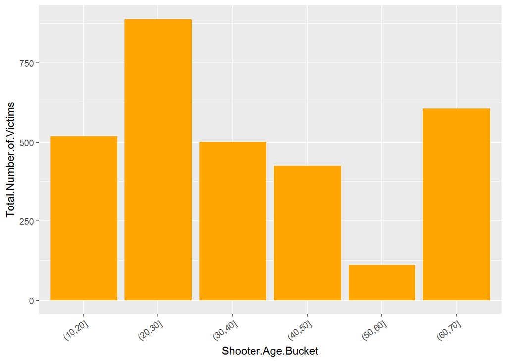

Shooters ages 20 to 30 are the most deadly.

### Motive and Total Victims

Are some motives more deadly than others?

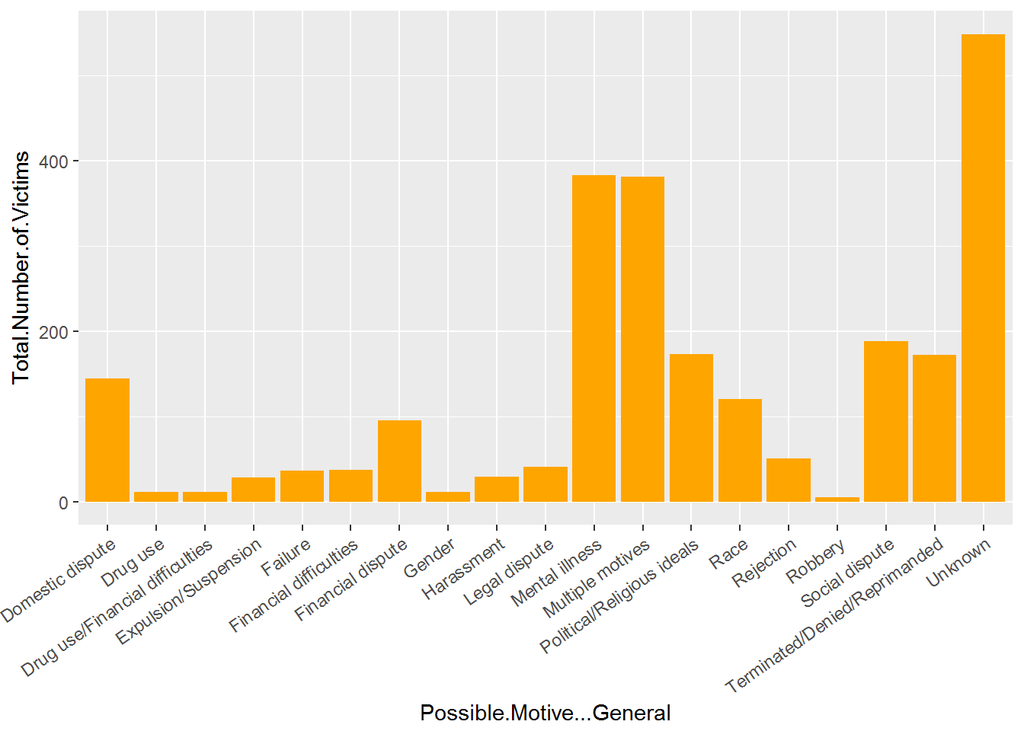

Previously, it was observed that domestic and social disputes were behind as  
many shootings as mental illness. However, we see that mental illness is  
responsible for as many victims as both of these combined. The top most deadly  
known individual motives are:

1. Mental illness
2. Social dispute
3. Political/Religious ideals
4. Terminated/Denied/Reprimanded
5. Domestic dispute
6. Race
7. Financial dispute

# Bivariate Analysis

### Talk about some of the relationships you observed in this part of the investigation. How did the feature(s) of interest vary with other features in the dataset?

The number of fatalities and victims for each shooting has remained mostly  
constant over time. There are some shootings in the past 5 to 10 years that  
have an unusually high number of victims. It is possible that recent shooters  
attempt to outdo previous shooters. More data would be required to confirm such  
a trend. This is data I hope we won’t collect.

### Did you observe any interesting relationships between the other features (not the main feature(s) of interest)?

Shooters have various motives and some of these tend to be dependent on age. In  
some cases, different age groups also tend to target different types of places.  
This is likely due to the type of facilities they often interact with and may  
be related to their motives. For example, young shooters targeted primary and  
secondary schools and one major motivation for this group was expulsion or  
suspension from these institutions.

### What was the strongest relationship you found?

This is a complex societal issue with many contributing factors, many of which  
probably are not captured in this dataset. No strong relationships were found  
and this is probably not likely for any small set of variables given the  
complexity of the problem. However, some variables explain certain aspects. The  
relationship of age with motive as well as how deadly different motives are  
were the most impressive to me. Perhaps a greater understanding of the shooters  
themselves would help shed light on unfathomable phenomenon and maybe even lead  
to more effective prevention measures.

# Multivariate Plots Section

In this section I will explore more about the shooters and their motives.

### Geographical Distribution of Motives

We’ve established the top 7 deadliest motives overall. Do these cluseter in  
certain regions?

[figure not shown]

Every motive is observed from coast to coast. No distinct clusters are apparent  
for any particular motive.

### Total Victims, Motives, and Time

How do the top motives trend with time? Are there motives that are more  
currently of concern?

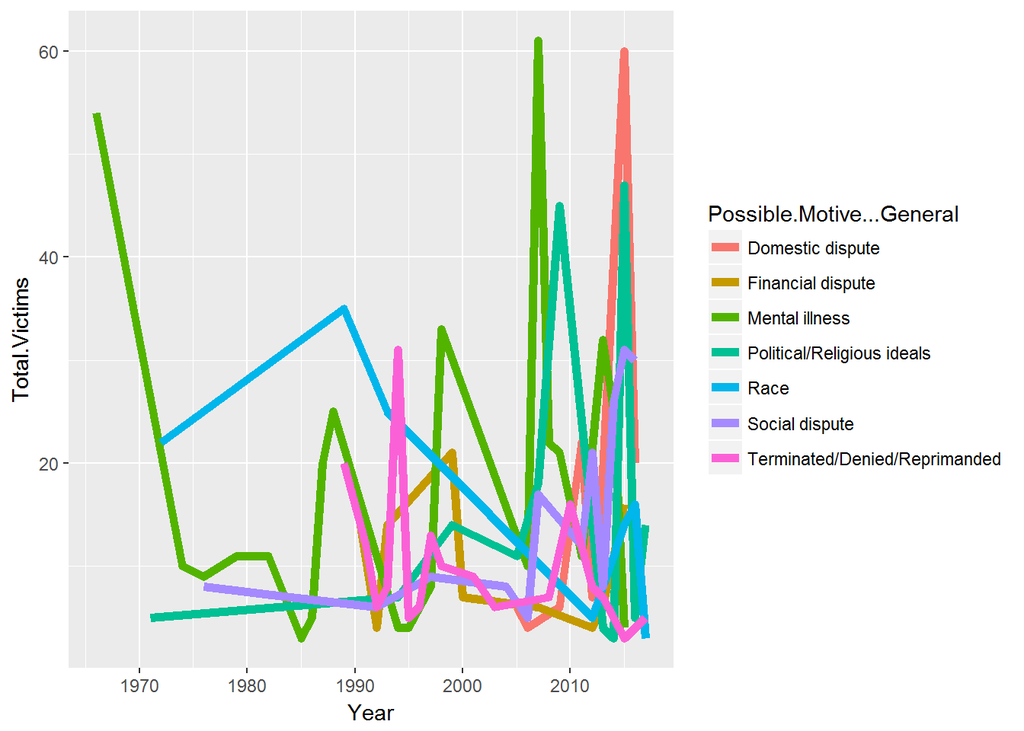

Viewing all three variables on a single plot is far too busy. Let’s break this  
up and look at each motive on a separate plot.

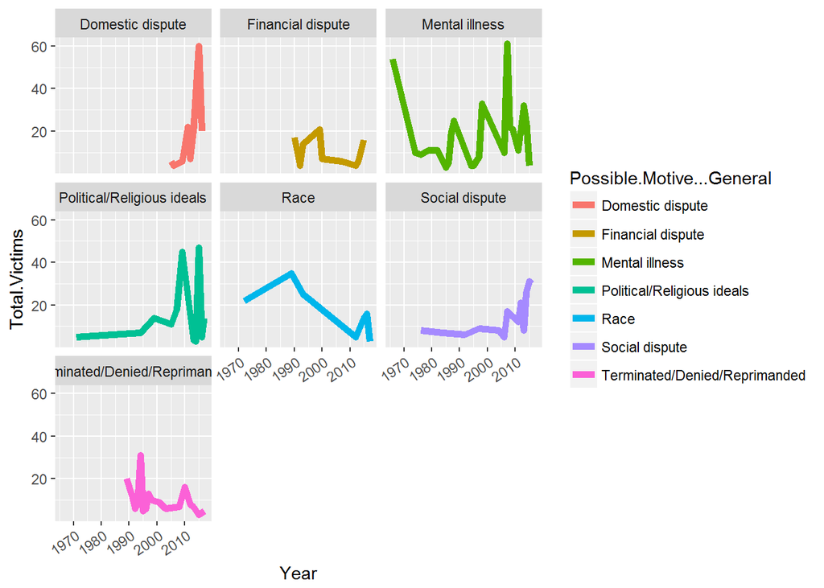

Mental illness has been a dominant factor throughout the years. Domestic  
and social disputes as well as political and religious ideals have seen an  
increase in the last 10 years. Financial disputes and employment issues such as  
termination have remained a constant influence. At least one encouraging aspect  
is that race has had a diminishing influence on mass shootings.

### Total Victims, Motives, and Shooter Age

Previously we identified the top most deadly motives. We saw certain motives  
are associated with age. How do different age groups associate with these  
motives?

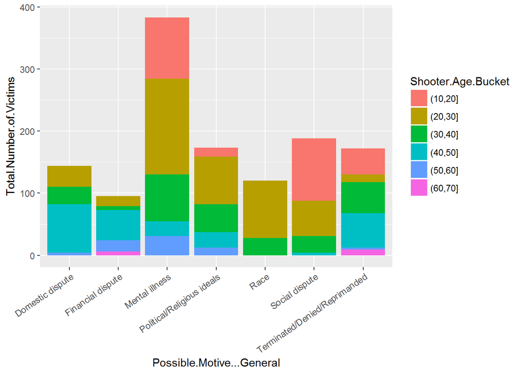

It appears that shooters ages 10 to 30 dominate the motives from mental illness  
to social disputes. This should be considered high risk age groups for these  
particular challenges and require special attention.

### Total Victims, Type of Victim and Shooter Age

Who do the different age groups of shooters target? Which are the most targeted  
types of victims?

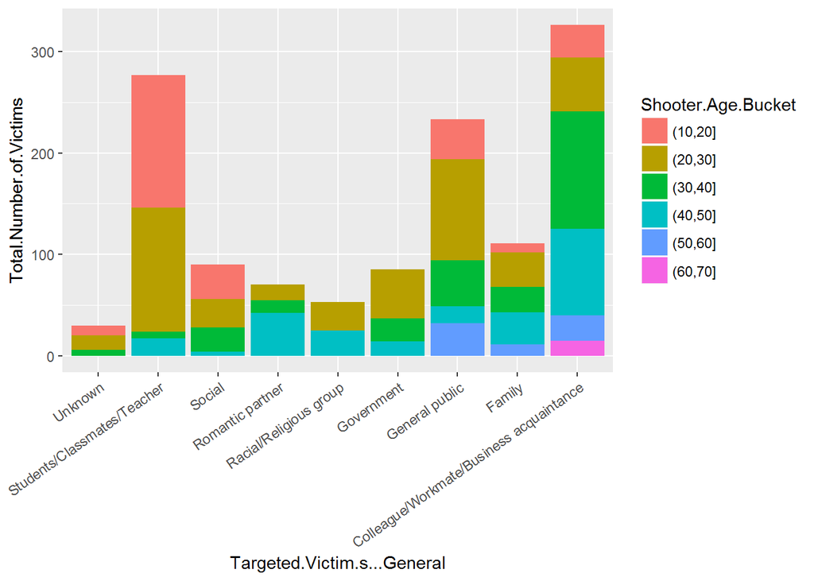

It appears that places of work and school are where shooters target most.  
Creating awareness of possible violence in these settings could help reduce  
future shootings.

# Multivariate Analysis

### Talk about some of the relationships you observed in this part of the investigation. Were there features that strengthened each other in terms of looking at your feature(s) of interest?

In this section, I explored the motives of shooters. Specifically I looked at  
whether motives were influenced by geographical location and whether they have  
changed with time. Looking at the time component for each motive revealed that  
some have changed over time and certain motives of special concern in recent  
history. I also looked at what challenges motivate different age groups and  
what types of victims they target. Looking at all these variables together  
showed that certain age groups are at a higher risk for responding violently to  
certain challenges and that they tend to target particular relationships.

### Were there any interesting or surprising interactions between features?

I was surprised to see that race is a declining factor in mass shootings. It  
was revealing to see that a younger demographic is more susceptible to violence  
with mental illness. This is a problem that requires speciall attention. Also,  
conflict at work and school can have serious consequences. Careful measures  
should be implemented to facilitate peaceful conflict resolution in these  
settings.

# Final Plots and Summary

### Plot One

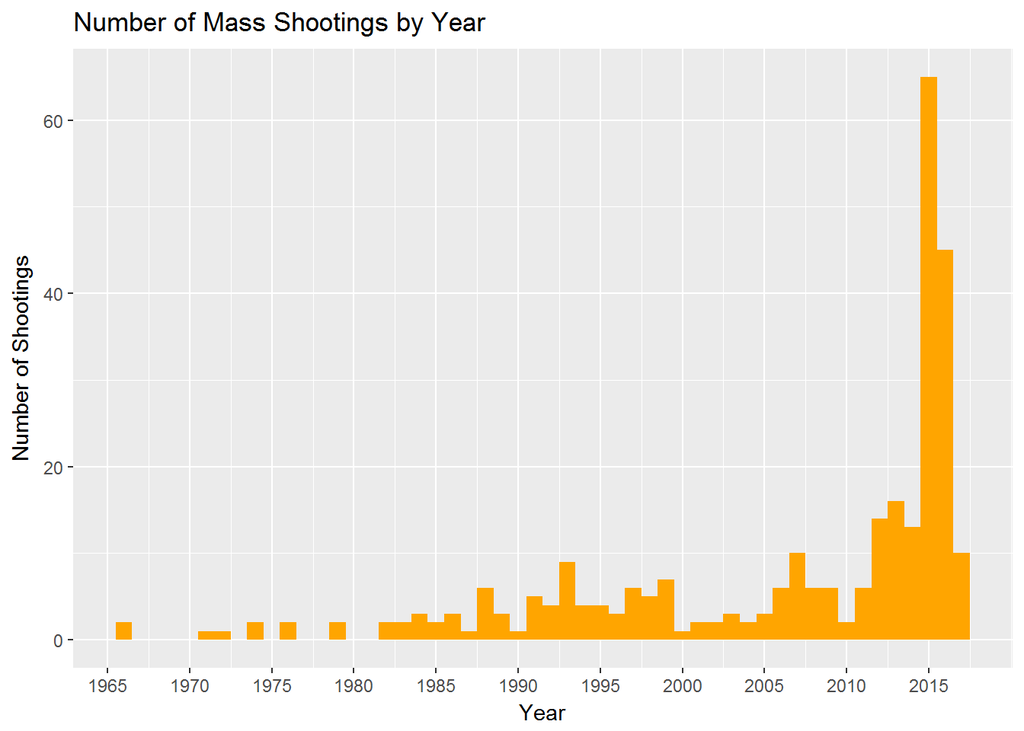

### Description One

This was the first plot in the investigation that alerted me to the serious  
problem we have with mass shootings. These are increasing in frequency and pose  
a great threat to public safety.

### Plot Two

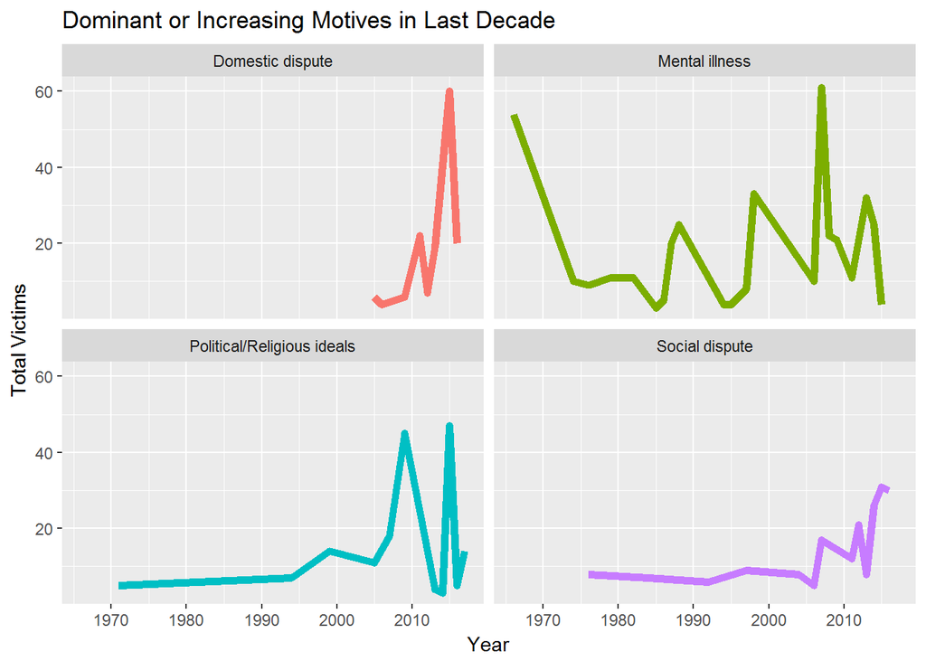

### Description Two

This plot illustrates the social challenges that are of greatest concern in  
recent history. Four motives were identified that are dominant or increasing  
within the past decade:

1. Domestic dispute. This motive was first recorded as a factor in a 2005  
   shooting. It continued to increase in frequency until it became the most deadly  
   motive in 2015.
2. Mental illness. This has continued to be one of the dominant factors behind  
   mass shootings. Mental illness has always been a concern in society and appears  
   to have had a constant risk of violence.
3. Political and religious ideals. This is also increasing in frequency. It’s  
   not surprising given the political and religious polarization that is so  
   evident in media.
4. Social dispute. This is a general description of conflicts that may occur  
   with friends, schoolmates, associates, or strangers. These violent encounters  
   are an increasing concern.

Efforts should be implemented to provide support for those with in these  
challenges in these areas. For example, greater awareness and assistance should  
be provided for those with mental illness, realizing that there is a small  
possibility of violence if it remains unaddressed. It also occurs to me that we  
could do more as a society to reduce polarization. Each group of people sharing  
certain ideals represent a distribution. As harsh rhetoric builds and opponents  
are increasingly demonized, it only reasons that more and more of the tail ends  
of those within ideological groups will be pushed over social barriers and take  
to violence. The more we can unite and work to understand each other’s  
differences, we may be able to discourage extreme violent reactions.

### Plot Three

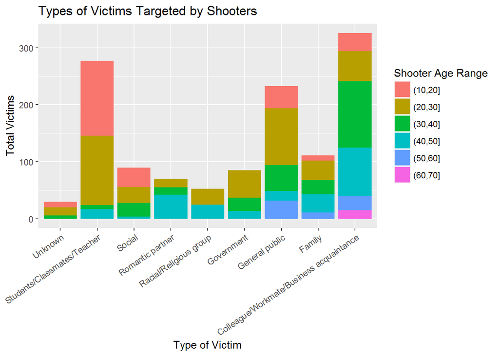

### Description Three

This plot highlights two types of victims that are most frequently targeted.  
Comparing this data to the bar plot of place type reveals that places of work  
and school are common targets. These are two areas where efforts should be  
applied to create awareness of violence and implement prevention measures.

# Reflection

Mass shootings are a tragic and highly complex societal issue in the United  
States. While admittedly incomplete, this dataset captures many important  
variables that provide valuable insight. My initial exploration confirmed my  
suspicion that mass shootings are a growing problem with a marked increase in  
recent years. As I dug deeper into the data, these events appeared random and  
it was difficult to find strong correlations in the data. However, I was able  
to find several associations that were intriguing and some that were surprising.

In the beginning of my exploration I was interested in victims, locations,  
weapons, and other other variables external to the shooters. As my work  
progressed, I noticed my focus shift to the shooters themselves. What were  
their motives, their ages, and the relationships they target? I began to see  
associations of motive and shooting location were related to age. I began to  
get a sense that there are certain intense challenges that may drive  
individuals to reacting in violent ways, especially when they have a  
predisposition to certain emotional difficulties. It was found that mental  
illness plays a large factor, but there may be other variables to consider as  
well.

There are several other variables within this dataset that should be explored.  
For example, a more detailed analysis of gun type could yield valuable  
information that could guide gun control efforts. Are there certain brands that  
are common and do these have distribution networks that could be improved? I  
started to dig into the type of place shootings occured, but I did not explore  
the shooters relationship to location. In addition, collection of more  
variables could be insightful. For example, economic status of the shooter or  
the economics of the area in which the shooter lives. This could help answer if  
there are financial stratas that are more at risk. Also, what about education  
level? It is my belief that if we dig into the details of what drives shooters  
to these atrocities, we can come together to create awareness of risk factors  
and implement prevention measures that will help reduce this terrible burden on  
society.